# MATH 3320 - PCA crypto

2023-11-18

## load libraries

```r
library(dplyr)
library(xts)
library(PerformanceAnalytics)
```

## Basic EDA

We first load the return series of cryptocurrencies

```r
dt <- read.csv("Crypto_Daily Return Series.csv", row.names =1)

head(dt)
```

```
##                  Date       MATIC        AVAX          SOL         EGLD
## 1 2020-11-18 23:59:59 -0.03451103 -0.02192227 -0.040379709 -0.044836647
## 2 2020-11-19 23:59:59  0.01041045 -0.03299708 -0.018255203  0.012209659
## 3 2020-11-20 23:59:59  0.03401361  0.02278797  0.008927327  0.002704792
## 4 2020-11-21 23:59:59  0.10042489  0.07556332  0.128285881  0.073147679
## 5 2020-11-22 23:59:59 -0.03721921 -0.02835707 -0.104959241 -0.023525376
## 6 2020-11-23 23:59:59  0.10594298  0.04485550  0.059517855  0.101277003
##           RUNE          QNT         HBAR          OKB        NEAR        ALGO
## 1 -0.115531346 -0.027733915 -0.022870124  0.114373266 -0.10928958 -0.02418648
## 2  0.006918416 -0.047034126 -0.004684125  0.066612755  0.01509352 -0.01097971
## 3  0.030550895  0.023654490  0.013946866  0.024148504  0.10397893  0.07231528
## 4 -0.011886494 -0.076018287  0.070731911  0.004490933  0.23163962  0.10311654
## 5 -0.080865367 -0.038833398  0.024622921  0.054612253 -0.09849915 -0.05967071
## 6  0.082420187 -0.005759746  0.036133372 -0.013232377  0.08841828  0.12081185
##            FTT          DOGE          MKR         ETC         VET          UNI
```

[output cut: 27 more lines]

Next, we convert to xts object for further analysis on time series

```r
dt_ts <- xts(x = dt[,-1], order.by = as.POSIXct(dt$Date, format = "%Y-%m-%d %H:%M:%S"))
head(dt_ts)
```

```
##                           MATIC        AVAX          SOL         EGLD
## 2020-11-18 23:59:59 -0.03451103 -0.02192227 -0.040379709 -0.044836647
## 2020-11-19 23:59:59  0.01041045 -0.03299708 -0.018255203  0.012209659
## 2020-11-20 23:59:59  0.03401361  0.02278797  0.008927327  0.002704792
## 2020-11-21 23:59:59  0.10042489  0.07556332  0.128285881  0.073147679
## 2020-11-22 23:59:59 -0.03721921 -0.02835707 -0.104959241 -0.023525376
## 2020-11-23 23:59:59  0.10594298  0.04485550  0.059517855  0.101277003
##                             RUNE          QNT         HBAR          OKB
## 2020-11-18 23:59:59 -0.115531346 -0.027733915 -0.022870124  0.114373266
## 2020-11-19 23:59:59  0.006918416 -0.047034126 -0.004684125  0.066612755
## 2020-11-20 23:59:59  0.030550895  0.023654490  0.013946866  0.024148504
## 2020-11-21 23:59:59 -0.011886494 -0.076018287  0.070731911  0.004490933
## 2020-11-22 23:59:59 -0.080865367 -0.038833398  0.024622921  0.054612253
## 2020-11-23 23:59:59  0.082420187 -0.005759746  0.036133372 -0.013232377
##                            NEAR        ALGO          FTT          DOGE
## 2020-11-18 23:59:59 -0.10928958 -0.02418648 -0.011923137 -0.0091909833
## 2020-11-19 23:59:59  0.01509352 -0.01097971 -0.011328718  0.0006941509
## 2020-11-20 23:59:59  0.10397893  0.07231528  0.050296315  0.0248682112
## 2020-11-21 23:59:59  0.23163962  0.10311654  0.024811357  0.1612654384
## 2020-11-22 23:59:59 -0.09849915 -0.05967071  0.004003507 -0.0518819836
## 2020-11-23 23:59:59  0.08841828  0.12081185  0.039930568  0.0914087768
##                              MKR         ETC         VET          UNI
## 2020-11-18 23:59:59 -0.028530213  0.04998466 -0.04449937 -0.093589423
## 2020-11-19 23:59:59 -0.002658402 -0.02354586 -0.02635917  0.074900996
## 2020-11-20 23:59:59  0.014578948  0.02177486  0.04537958  0.028482086
## 2020-11-21 23:59:59  0.038078217  0.08166257  0.17630701 -0.007496039
## 2020-11-22 23:59:59  0.034629148 -0.08675541 -0.03619979 -0.041009949
## 2020-11-23 23:59:59  0.064865391  0.08147007  0.14642662  0.135228547
##                             AAVE          FIL         ATOM           LEO
## 2020-11-18 23:59:59 -0.041795555 -0.012566748 -0.035780161 -0.0013968171
## 2020-11-19 23:59:59  0.008272101 -0.006339472 -0.001968934 -0.0249819799
## 2020-11-20 23:59:59 -0.010492628  0.013831962  0.034672756  0.0009768159
## 2020-11-21 23:59:59 -0.063822069  0.027208774  0.111394054 -0.0031803241
## 2020-11-22 23:59:59 -0.028802624 -0.006459328 -0.075428282  0.0100361310
## 2020-11-23 23:59:59  0.048687036 -0.017103940  0.059956975  0.0180558934
##                             CRO          XLM         TRX         XMR
## 2020-11-18 23:59:59  0.02244652 -0.028997856  0.01327238 -0.01436073
## 2020-11-19 23:59:59  0.01368851  0.003474185 -0.03875917 -0.04344404
## 2020-11-20 23:59:59  0.14295743  0.051123698  0.01794645  0.02138799
## 2020-11-21 23:59:59 -0.05620196  0.205049516  0.14388345  0.05722323
## 2020-11-22 23:59:59 -0.02555175 -0.046047995 -0.05541596 -0.03766216
## 2020-11-23 23:59:59  0.01816898  0.232308424  0.09857178  0.05178493
##                              ADA           BNB         DOT         BCH
## 2020-11-18 23:59:59 -0.029608274 -0.0160556768 -0.03465221 -0.03249583
## 2020-11-19 23:59:59 -0.005054925  0.0006387722  0.01634193 -0.00346971
## 2020-11-20 23:59:59  0.110420421  0.0280051503  0.09550002  0.04983885
## 2020-11-21 23:59:59  0.117339999  0.0505913140  0.09446584  0.15391034
## 2020-11-22 23:59:59  0.085143071 -0.0154594636 -0.04809070 -0.05071876
## 2020-11-23 23:59:59  0.058686480  0.0341728927  0.07468339  0.11827300
##                             LTC         XRP          ETH           BTC
## 2020-11-18 23:59:59 -0.02885455 -0.02744453 -0.001825297  0.0089480199
## 2020-11-19 23:59:59  0.10292010  0.03192279 -0.016515106  0.0007343962
## 2020-11-20 23:59:59  0.01095156  0.07696516  0.077714188  0.0441485148
## 2020-11-21 23:59:59  0.04529913  0.33439892  0.075074572  0.0011228135
## 2020-11-22 23:59:59 -0.04383429 -0.03247087  0.015496610 -0.0147105381
## 2020-11-23 23:59:59  0.07380745  0.32481214  0.086440316 -0.0003201383
```

Now we perform some basic calculations using the Performance Analytics library

### Summary Stat

```r
table.Stats(dt_ts)
```

```
##                     MATIC      AVAX       SOL      EGLD      RUNE       QNT
## Observations    1094.0000 1094.0000 1094.0000 1094.0000 1094.0000 1094.0000
## NAs                0.0000    0.0000    0.0000    0.0000    0.0000    0.0000
## Minimum           -0.3914   -0.4541   -0.5496   -0.3957   -0.5534   -0.3192
## Quartile 1        -0.0308   -0.0309   -0.0320   -0.0281   -0.0345   -0.0260
## Median             0.0004    0.0005   -0.0003    0.0000   -0.0010   -0.0026
## Arithmetic Mean    0.0035    0.0016    0.0030    0.0016    0.0016    0.0017
## Geometric Mean     0.0011   -0.0007    0.0005   -0.0002   -0.0013    0.0000
## Quartile 3         0.0303    0.0315    0.0346    0.0273    0.0375    0.0264
## Maximum            0.4578    0.5596    0.3053    0.3803    0.3314    0.3547
## SE Mean            0.0021    0.0021    0.0021    0.0018    0.0023    0.0018
## LCL Mean (0.95)   -0.0007   -0.0025   -0.0011   -0.0019   -0.0028   -0.0018
## UCL Mean (0.95)    0.0077    0.0056    0.0071    0.0051    0.0061    0.0052
## Variance           0.0050    0.0047    0.0048    0.0035    0.0056    0.0034
## Stdev              0.0710    0.0683    0.0690    0.0588    0.0751    0.0586
## Skewness           1.0922    0.4819   -0.4380    0.2205   -0.2415    0.6726
## Kurtosis           7.6422    8.1601    7.3040    5.4633    4.7181    5.7709
##                      HBAR       OKB      NEAR      ALGO       FTT      DOGE
## Observations    1094.0000 1094.0000 1094.0000 1094.0000 1094.0000 1094.0000
## NAs                0.0000    0.0000    0.0000    0.0000    0.0000    0.0000
## Minimum           -0.4209   -0.4011   -0.4436   -0.3701   -1.3893   -0.5151
## Quartile 1        -0.0284   -0.0207   -0.0327   -0.0308   -0.0281   -0.0265
## Median             0.0006   -0.0001   -0.0003    0.0013    0.0005   -0.0006
## Arithmetic Mean    0.0006    0.0023    0.0006   -0.0006   -0.0001    0.0030
## Geometric Mean    -0.0011    0.0006   -0.0018   -0.0023       NaN   -0.0001
## Quartile 3         0.0259    0.0217    0.0347    0.0271    0.0290    0.0213
## Maximum            0.4585    0.4890    0.3610    0.4182    0.6671    1.5164
## SE Mean            0.0018    0.0017    0.0021    0.0017    0.0026    0.0026
## LCL Mean (0.95)   -0.0029   -0.0012   -0.0035   -0.0041   -0.0052   -0.0021
## UCL Mean (0.95)    0.0041    0.0057    0.0046    0.0028    0.0049    0.0081
## Variance           0.0035    0.0033    0.0047    0.0033    0.0072    0.0074
## Stdev              0.0595    0.0577    0.0684    0.0577    0.0848    0.0861
## Skewness           0.6266    1.2661   -0.0402    0.0495   -3.9631    5.8356
## Kurtosis           8.6285   17.9930    4.7841    6.0206   82.5266   96.1299
##                       MKR       ETC       VET       UNI      AAVE       FIL
## Observations    1094.0000 1094.0000 1094.0000 1094.0000 1094.0000 1094.0000
## NAs                0.0000    0.0000    0.0000    0.0000    0.0000    0.0000
## Minimum           -0.2827   -0.3886   -0.4090   -0.4035   -0.4129   -0.4262
## Quartile 1        -0.0265   -0.0243   -0.0287   -0.0295   -0.0327   -0.0272
## Median            -0.0002   -0.0001    0.0012    0.0004    0.0005   -0.0025
```

[output cut: 47 more lines]

```
## NAs                0.0000    0.0000
## Minimum           -0.3175   -0.1741
## Quartile 1        -0.0185   -0.0145
## Median             0.0007   -0.0003
## Arithmetic Mean    0.0013    0.0007
## Geometric Mean     0.0003    0.0001
## Quartile 3         0.0235    0.0167
## Maximum            0.2307    0.1718
## SE Mean            0.0014    0.0010
## LCL Mean (0.95)   -0.0014   -0.0014
## UCL Mean (0.95)    0.0039    0.0027
## Variance           0.0020    0.0012
## Stdev              0.0449    0.0343
## Skewness          -0.3997   -0.2012
## Kurtosis           5.1275    3.3718
```

### Cumulative Return

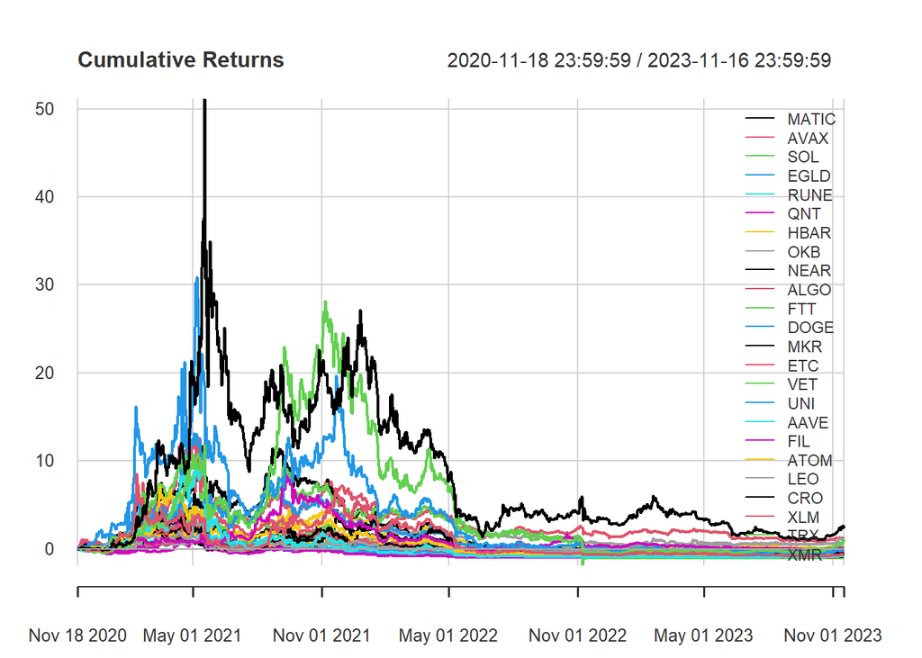

```r
chart.CumReturns(dt_ts, legend="topright", main="Cumulative Returns")
```

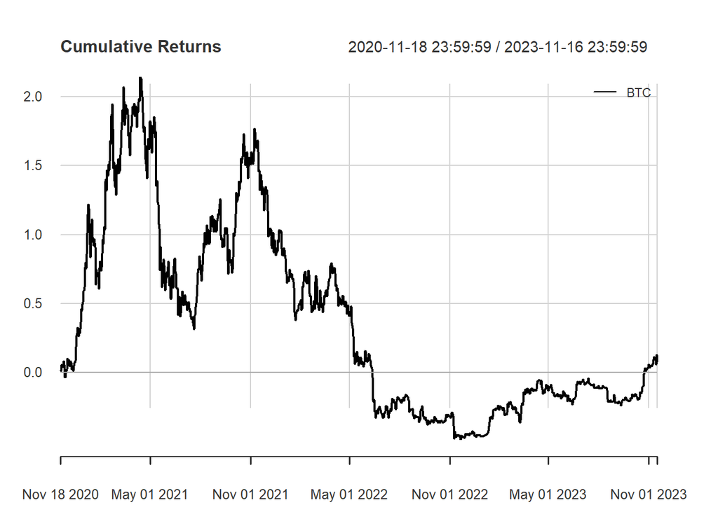

```r
chart.CumReturns(dt_ts$BTC, legend="topright", main="Cumulative Returns")
```

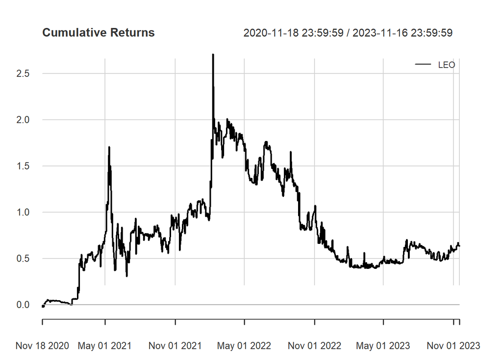

```r
chart.CumReturns(dt_ts$LEO, legend="topright", main="Cumulative Returns")
```

### Correlation Chart

I included a truncated version of the correlation chart for simplicity, but we can see correlations were generally positive for the past three years.

```r
cor(dt_ts)[1:8, 1:8]
```

```
##           MATIC      AVAX       SOL      EGLD      RUNE       QNT      HBAR
## MATIC 1.0000000 0.6037338 0.5545271 0.5492716 0.5856119 0.4059309 0.5338072
## AVAX  0.6037338 1.0000000 0.5855086 0.5875041 0.5977639 0.4855712 0.5522681
## SOL   0.5545271 0.5855086 1.0000000 0.5011198 0.5990235 0.4721721 0.5160019
## EGLD  0.5492716 0.5875041 0.5011198 1.0000000 0.5500316 0.3827700 0.5006073
## RUNE  0.5856119 0.5977639 0.5990235 0.5500316 1.0000000 0.4561165 0.5049470
## QNT   0.4059309 0.4855712 0.4721721 0.3827700 0.4561165 1.0000000 0.4489550
## HBAR  0.5338072 0.5522681 0.5160019 0.5006073 0.5049470 0.4489550 1.0000000
## OKB   0.4726976 0.4438393 0.4601056 0.4097780 0.4301481 0.3279344 0.4437143
##             OKB
## MATIC 0.4726976
## AVAX  0.4438393
## SOL   0.4601056
## EGLD  0.4097780
## RUNE  0.4301481
## QNT   0.3279344
## HBAR  0.4437143
## OKB   1.0000000
```

## PCA Analysis

To do PCA, we use prcomp() in R, which uses the SVD method. We demean the matrix and set sd to 1, following conventions of Avellaneda

```r
dt_ts.pc <- prcomp(dt_ts, center = TRUE, scale. = TRUE)
summary(dt_ts.pc)
```

```
## Importance of components:
##                           PC1     PC2     PC3     PC4    PC5     PC6     PC7
## Standard deviation     4.2270 1.04733 1.02234 0.92979 0.9122 0.89651 0.84778
## Proportion of Variance 0.5584 0.03428 0.03266 0.02702 0.0260 0.02512 0.02246
## Cumulative Proportion  0.5584 0.59263 0.62529 0.65231 0.6783 0.70343 0.72589
##                            PC8     PC9    PC10    PC11    PC12    PC13    PC14
## Standard deviation     0.81324 0.78724 0.71498 0.70101 0.68982 0.68261 0.67383
## Proportion of Variance 0.02067 0.01937 0.01597 0.01536 0.01487 0.01456 0.01419
## Cumulative Proportion  0.74655 0.76592 0.78190 0.79725 0.81212 0.82668 0.84087
##                           PC15    PC16    PC17    PC18    PC19   PC20    PC21
## Standard deviation     0.66290 0.64811 0.62322 0.61789 0.60565 0.6014 0.57673
## Proportion of Variance 0.01373 0.01313 0.01214 0.01193 0.01146 0.0113 0.01039
## Cumulative Proportion  0.85460 0.86773 0.87987 0.89180 0.90326 0.9146 0.92496
##                           PC22    PC23    PC24    PC25    PC26    PC27    PC28
## Standard deviation     0.55862 0.52961 0.52367 0.49608 0.47983 0.46129 0.44401
## Proportion of Variance 0.00975 0.00877 0.00857 0.00769 0.00719 0.00665 0.00616
## Cumulative Proportion  0.93471 0.94348 0.95205 0.95974 0.96693 0.97358 0.97974
##                           PC29    PC30    PC31    PC32
## Standard deviation     0.43854 0.42444 0.39359 0.34771
## Proportion of Variance 0.00601 0.00563 0.00484 0.00378
## Cumulative Proportion  0.98575 0.99138 0.99622 1.00000
```

Interestingly, see that 55.8% of variance is explained by the first PC. Next, we check the first three loadings.

```r
dt_ts.pc$rotation[,1:3]
```

```
##              PC1          PC2          PC3
## MATIC 0.18202219  0.092492243 -0.067395865
## AVAX  0.17893806  0.186495342 -0.133165409
## SOL   0.16957629  0.298176300 -0.115573024
## EGLD  0.16781278  0.125127568 -0.107007396
## RUNE  0.18258909  0.129929447 -0.094394813
## QNT   0.13958304  0.054580148 -0.287804850
## HBAR  0.16971430  0.016537916 -0.100329200
## OKB   0.14528226  0.175135571  0.176309689
## NEAR  0.17329324  0.182494035 -0.135328136
## ALGO  0.19404582  0.016720928 -0.053137748
## FTT   0.14047706  0.194014393 -0.040480687
## DOGE  0.12161643 -0.363432261  0.029030300
## MKR   0.16915106  0.010587604 -0.038340219
## ETC   0.18636161 -0.250211092  0.125740471
## VET   0.20244110 -0.121360508  0.011074816
## UNI   0.18751860  0.071596384 -0.142415149
## AAVE  0.19109359  0.163968929 -0.127509321
## FIL   0.17049792 -0.009328300  0.003782960
## ATOM  0.18624747  0.102672424 -0.087725125
## LEO   0.02907652  0.474701961  0.754237389
## CRO   0.17449417 -0.031400300 -0.030575392
## XLM   0.18280623 -0.209728804  0.195042692
## TRX   0.18091367 -0.215528674  0.136672903
## XMR   0.17640851 -0.097252042  0.128615619
## ADA   0.19413526 -0.034490514 -0.001028704
## BNB   0.18690515  0.122896577  0.112429316
## DOT   0.20206419  0.023580244 -0.070148107
## BCH   0.19211769 -0.263667463  0.167771890
## LTC   0.20352291 -0.186065278  0.078834085
## XRP   0.16749037 -0.164339130  0.183052541
## ETH   0.21164603  0.005153415  0.028079396
## BTC   0.20009243 -0.060403917  0.073879305
```

As seen above, the first loading vector is non-negative, consistent with literature.

### Visualization of PCA

Next, we take a look at some plots

```r
library(factoextra)
```

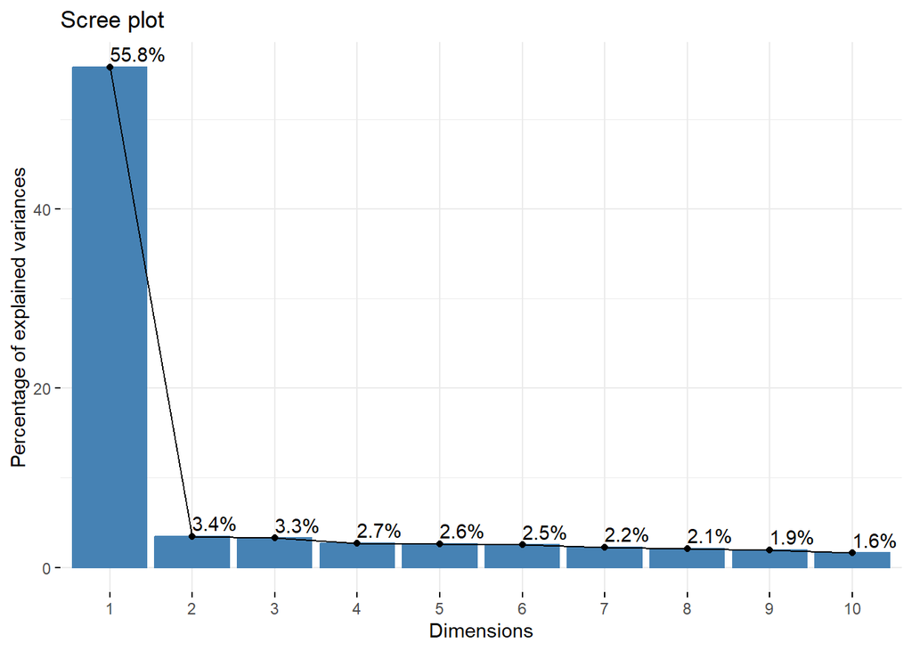

```r
fviz_eig(dt_ts.pc, addlabels = TRUE)
```

Next we look at the biplot.

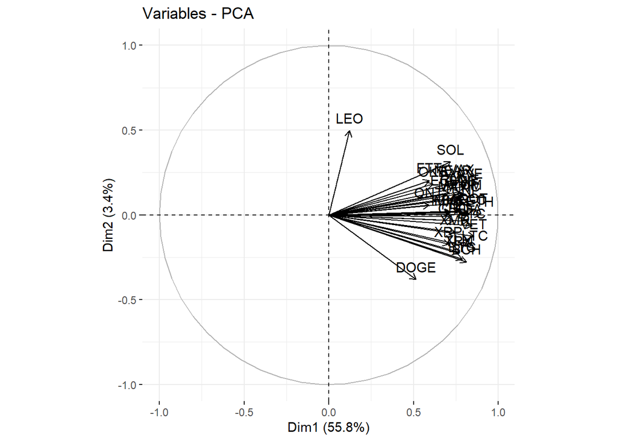

```r
# Graph of the variables
fviz_pca_var(dt_ts.pc, col.var = "black")
```

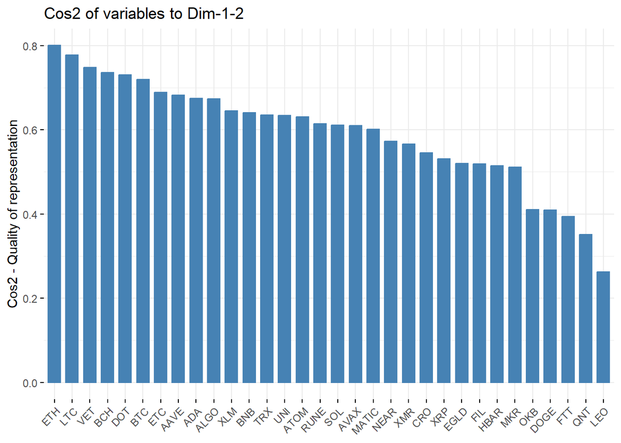

```r
fviz_cos2(dt_ts.pc, choice = "var", axes = 1:2)
```

Combining contribution and influence, we can create the below plot.

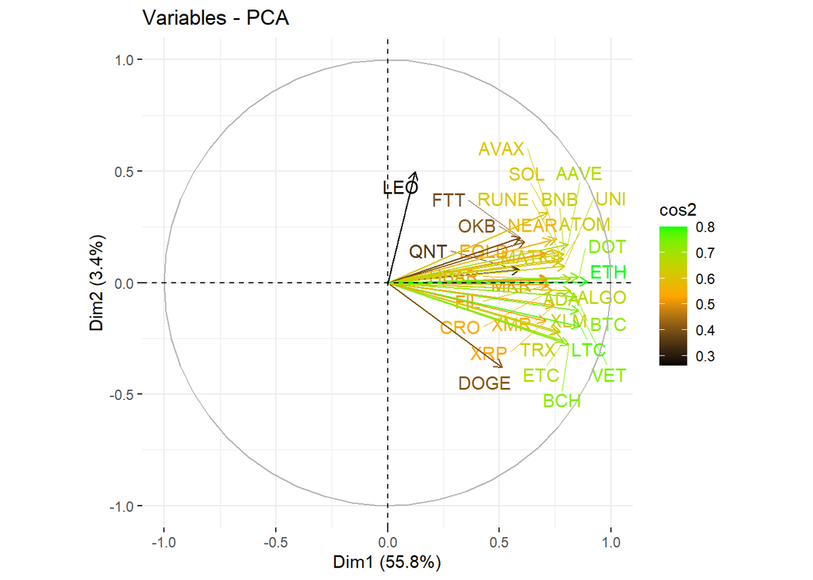

```r
fviz_pca_var(dt_ts.pc, col.var = "cos2",
            gradient.cols = c("black", "orange", "green"),
            repel = TRUE)
```

Overall, the clustering of most cryptocurrencies on the right hand side signifies that most cryptocurrencies are positively correlated to our *Dim1* and follow a similar pattern.

## Eigenportfolio analysis

Next, we try to find eigenportfolios by interpreting the elements of our principal component vectors as weights for each cryptocurrency. First, we take the main principal component and construct the eigenportfolio.

Again, following conventions, we divide each element by the standard deviation of the corresponding cryptocurrency, and then left multiply its transpose with our original data matrix.

```r
# Find weighting by dividing by each asset's standard deviation.
sd.ret <- table.Stats(dt_ts)["Stdev",] %>% as.numeric()

# Find sum of components
sum.wgts <- (dt_ts.pc$rotation[,1] / sd.ret)  %>% sum()
sum.wgts
```

```
## [1] 97.86727
```

Notice how values are close to 100. Next, we normalize them so the sum becomes 1.

```r
# Find normalized wgts for principal eigenportfolio
normalized.wgts <- (dt_ts.pc$rotation[,1] / sd.ret) / sum.wgts

cat(normalized.wgts, "\n", "Sum of weights:", sum(normalized.wgts))
```

[output not shown]

Next, we find the returns of this eigenportfolio.

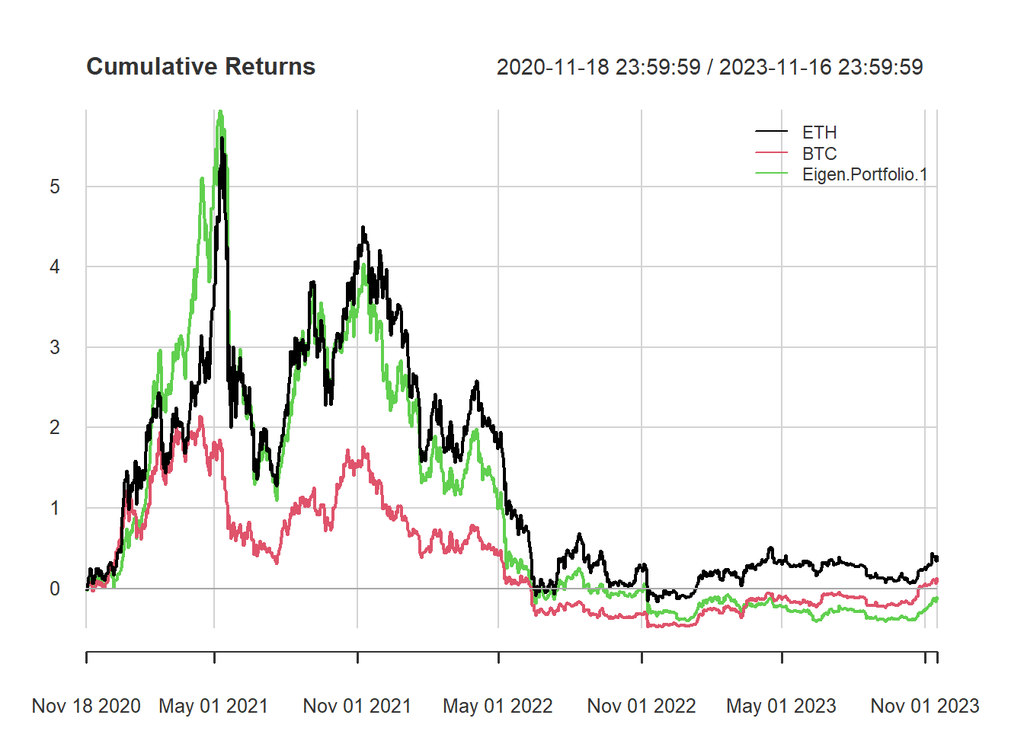

```r
# Convert to matrix form for matrix algebra
nwgts_mat <- matrix(normalized.wgts, nrow = 1)
nwgts_mat <- t(nwgts_mat)

dt_mat <- as.matrix(dt) %>% apply(2, function(x) as.numeric(x))
dt_mat <- dt_mat[,-1]

# Compute eigenportfolio 1 return
egnportfolio1_ret <- dt_mat %*% nwgts_mat
egnportfolio1_ret <- xts(x = egnportfolio1_ret, order.by = as.POSIXct(dt$Date, format = "%Y-%m-%d %H:%M:%S"))
colnames(egnportfolio1_ret) <- "Eigen Portfolio 1"

# Compare Return with BTC and ETHereum
chart.CumReturns(cbind(dt_ts$ETH, dt_ts$BTC, egnportfolio1_ret),legend="topright", main="Cumulative Returns")
```

One interesting feature of our “market” factor is that its return seems to be tracking that of Ethereum more than BTC. One reason for this could be that most cryptocurrencies display higher correlation with returns of Etherum vs those of BTC. We do a simple check by looking at the correlation matrix.

```r
cor.ret <- cor(cbind(dt_ts, egnportfolio1_ret))
cor.ret[,c("BTC", "ETH", "Eigen.Portfolio.1")] %>% colSums()
```

```
##               BTC               ETH Eigen.Portfolio.1
##          20.70739          21.87418          24.50165
```

Now we try to see what the return profile of our remaining portfolios are.

### Eigenportfolio2

From principal component 2 and onwards, we see that the elements contain negative values, which makes sense since each principal component must be orthogonal to each other.

Thus, we must deal with the issue of negative weightings. In this analysis, we assume negative weightings imply that investors take a “short-sale” of the corresponding cryptocurrency.

This is a plausible assumption to make, since most cryptocurrencies are easy to short-sell.

Normalization is done by taking the sum of the *absolute value* of the elements.

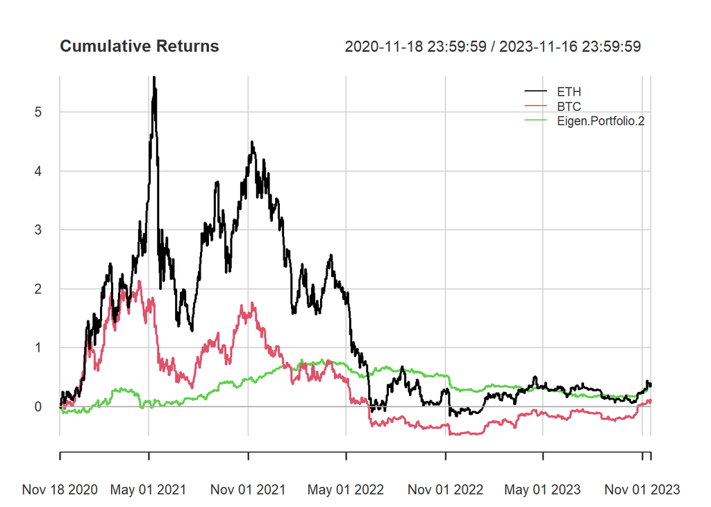

```r
# sum of wgts
sum.wgts2 <- (dt_ts.pc$rotation[,2] / sd.ret)  %>% abs() %>% sum()

# Find normalized weights for principal eigenportfolio2
normalized.wgts2 <- (dt_ts.pc$rotation[,2] / sd.ret) / sum.wgts2

# Convert to matrix form for matrix algebra
nwgts_mat2 <- matrix(normalized.wgts2, nrow = 1)
nwgts_mat2 <- t(nwgts_mat2)

# Compute eigenportfolio 1 return
egnportfolio2_ret <- dt_mat %*% nwgts_mat2
egnportfolio2_ret <- xts(x = egnportfolio2_ret, order.by = as.POSIXct(dt$Date, format = "%Y-%m-%d %H:%M:%S"))
colnames(egnportfolio2_ret) <- "Eigen Portfolio 2"

# Compare Return with BTC and ETHereum
chart.CumReturns(cbind(dt_ts$ETH, dt_ts$BTC, egnportfolio2_ret),legend="topright", main="Cumulative Returns")
```

We also verify that the Eigenportfolio2 and Eigenportfolio1 are not correlated.

```r
cor(egnportfolio1_ret, egnportfolio2_ret)
```

```
##                   Eigen Portfolio 2
## Eigen Portfolio 1      3.721975e-05
```

### Eigenportfolio3

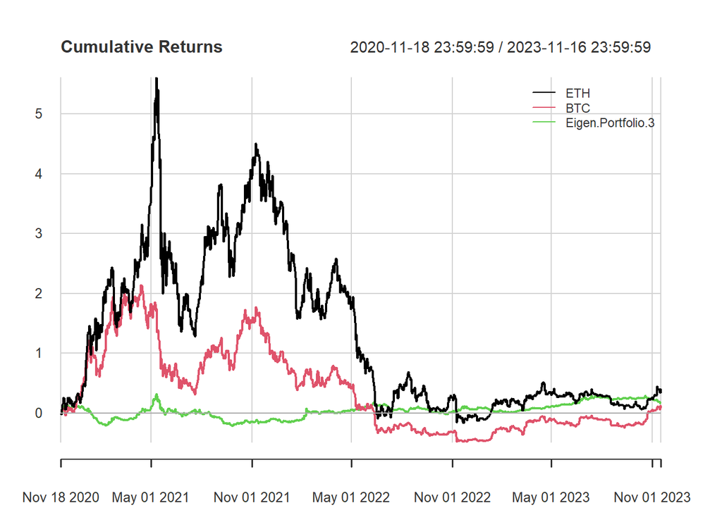

```r
# sum of wgts
sum.wgts3 <- (dt_ts.pc$rotation[,3] / sd.ret)  %>% abs() %>% sum()

# Find normalized weights for principal eigenportfolio2
normalized.wgts3 <- (dt_ts.pc$rotation[,3] / sd.ret) / sum.wgts3

# Convert to matrix form for matrix algebra
nwgts_mat3 <- matrix(normalized.wgts3, nrow = 1)
nwgts_mat3 <- t(nwgts_mat3)

# Compute eigenportfolio 1 return
egnportfolio3_ret <- dt_mat %*% nwgts_mat3
egnportfolio3_ret <- xts(x = egnportfolio3_ret, order.by = as.POSIXct(dt$Date, format = "%Y-%m-%d %H:%M:%S"))
colnames(egnportfolio3_ret) <- "Eigen Portfolio 3"

# Compare Return with BTC and ETHereum
chart.CumReturns(cbind(dt_ts$ETH, dt_ts$BTC, egnportfolio3_ret),legend="topright", main="Cumulative Returns")
```

We check correlations for three portfolios.

```r
cor(data.frame(egnportfolio1_ret, egnportfolio2_ret, egnportfolio3_ret))
```

```
##                   Eigen.Portfolio.1 Eigen.Portfolio.2 Eigen.Portfolio.3
## Eigen.Portfolio.1      1.000000e+00      3.721975e-05      0.0004092523
## Eigen.Portfolio.2      3.721975e-05      1.000000e+00      0.0011554345
## Eigen.Portfolio.3      4.092523e-04      1.155435e-03      1.0000000000
```

We verify that the three portfolios contain orthogonal information.

## Diversification using Eigenportfolios

If we take a look at the summary statistics, we see that Eigenportfolios 2 and 3 have low but more relatively stable returns.

```r
table.Stats(cbind(egnportfolio1_ret, egnportfolio2_ret, egnportfolio3_ret, dt_ts$BTC, dt_ts$ETH))
```

```
##                 Eigen.Portfolio.1 Eigen.Portfolio.2 Eigen.Portfolio.3       BTC
## Observations            1094.0000         1094.0000         1094.0000 1094.0000
## NAs                        0.0000            0.0000            0.0000    0.0000
## Minimum                   -0.3792           -0.0953           -0.0737   -0.1741
## Quartile 1                -0.0174           -0.0052           -0.0059   -0.0145
## Median                     0.0031            0.0001            0.0001   -0.0003
## Arithmetic Mean            0.0008            0.0004            0.0002    0.0007
## Geometric Mean            -0.0001            0.0003            0.0001    0.0001
## Quartile 3                 0.0238            0.0060            0.0064    0.0167
## Maximum                    0.2258            0.0849            0.1351    0.1718
## SE Mean                    0.0013            0.0004            0.0004    0.0010
## LCL Mean (0.95)           -0.0017           -0.0004           -0.0006   -0.0014
## UCL Mean (0.95)            0.0034            0.0012            0.0010    0.0027
## Variance                   0.0019            0.0002            0.0002    0.0012
## Stdev                      0.0432            0.0132            0.0136    0.0343
## Skewness                  -1.1317           -0.1459            0.9964   -0.2012
## Kurtosis                   8.2572            9.1127           13.5744    3.3718
##                       ETH
## Observations    1094.0000
## NAs                0.0000
## Minimum           -0.3175
## Quartile 1        -0.0185
## Median             0.0007
## Arithmetic Mean    0.0013
## Geometric Mean     0.0003
## Quartile 3         0.0235
## Maximum            0.2307
## SE Mean            0.0014
## LCL Mean (0.95)   -0.0014
## UCL Mean (0.95)    0.0039
## Variance           0.0020
## Stdev              0.0449
## Skewness          -0.3997
## Kurtosis           5.1275
```

Now, we take a look at the risk-adjusted measure, also known as the Sharpe Ratio (we assume a risk free rate of 0% for simplicity).

```r
apply(cbind(egnportfolio1_ret, egnportfolio2_ret, egnportfolio3_ret, dt_ts$BTC, dt_ts$ETH), 2,  SharpeRatio)[1,]
```

```
## Eigen.Portfolio.1 Eigen.Portfolio.2 Eigen.Portfolio.3               BTC
##        0.01925718        0.02858500        0.01669299        0.01914406
##               ETH
##        0.02866391
```

We see that the Sharpe Ratio of eigenportfolio 2 and ETH are very similar, but the correlation between them are near zero. Then, allocating half of our wealth to Eigenportfolio2 and Ethereum should have in theory produced better risk-adjusted returns.

```r
SharpeRatio(0.5 * egnportfolio2_ret + 0.5 * dt_ts$ETH)[1,1]
```

```
## [1] 0.03552542
```

Now, we can go further, since eigenportfolios have zero correlations to each other.

```r
SharpeRatio(0.33 * egnportfolio2_ret + 0.33 * dt_ts$ETH + 0.33 * egnportfolio3_ret)[1,1]
```

```
## [1] 0.03848537
```

We observe that our Sharpe Ratio of diversified portfolio is higher than when we have not diversified.

## Practical Implications

Now, this analysis assumes that factors are static. However, that is not true in reality. The probability distribution implied the markets constantly changes, which is dependent on numerous factors. Therefore, to verify that diversifying one’s wealth using the concept of eigenportfolios provides better risk-adjusted returns, we must conduct a rigorous study employing in-sample and out-of-sample data.